# Introduction to Regression Notes

Daniel Osborne

19 May 2023

## Data and libraries

R libraries we will use in this analysis:

```r
library(haven)
library(tidyverse)
library(knitr) # for the kable() function
library(patchwork)
library(scales)
```

Data for these exercises is from the *Introduction to Linear and Logistic Regression* short course.

```r
asthma_trial <- read_dta("asthma_trial.dta")
perulung <- read_dta("perulung.dta")
onch <- read_dta("ONCH1302 (1).dta")
astnutr <- read_dta("astnutr.dta")
```

## Linear Regression

### What is linear regression?

Linear regression is a mathematical formula that works out the best possible straight line that fits the data when plotted on a scatter diagram. It is used for continuous outcome variables. For example, the speed of a car and its stopping distance. You’d expect the faster a car is travelling, the greater distance it would require to stop.

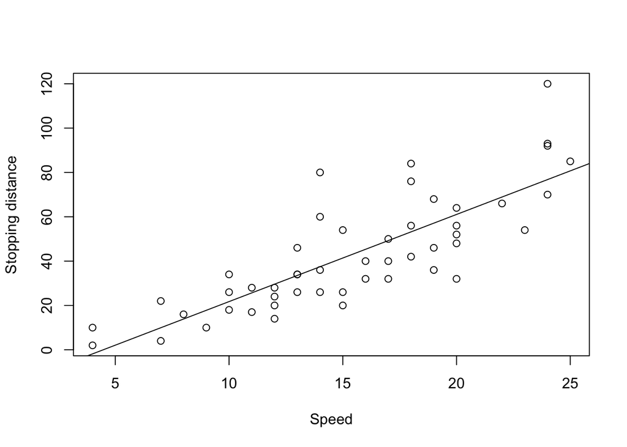

### Crude model

The asthma trial randomised children into one of two arms:

1. Treatment
2. Placebo

FEV1 is a spirometry measurement and was collected at baseline (FEV0) and at 12 weeks (FEV12). A “crude” linear model can be used to estimate the effect of treatment arm on fev12 outcome measure:

```r
linear.model <- asthma_trial %>%
  lm(fev12 ~ treat, data = .)
linear.model %>% summary()
```

```
##
## Call:
## lm(formula = fev12 ~ treat, data = .)
##
## Residuals:
##      Min       1Q   Median       3Q      Max
## -1.62962 -0.52673 -0.04936  0.37827  2.25038
##
## Coefficients:
##             Estimate Std. Error t value Pr(>|t|)
## (Intercept)  1.87910    0.07986  23.531  < 2e-16 ***
## treat        0.32052    0.11042   2.903  0.00418 **
## ---
## Signif. codes:  0 '***' 0.001 '**' 0.01 '*' 0.05 '.' 0.1 ' ' 1
##
## Residual standard error: 0.7275 on 172 degrees of freedom
##   (9 observations deleted due to missingness)
## Multiple R-squared:  0.0467, Adjusted R-squared:  0.04115
## F-statistic: 8.425 on 1 and 172 DF,  p-value: 0.004185
```

You can get confidence intervals with the following code:

```r
linear.model %>% confint() # get confidence interval of beta values
```

```
##                 2.5 %    97.5 %
## (Intercept) 1.7214734 2.0367193
## treat       0.1025607 0.5384773
```

Beta ($\beta$) values are used to descibe the output. The y-intercept is a required for the mathematical model but an x value of 0 may not always make sense. The model output can be summarised with the following formula:
$$y = \beta_0 + \beta_1\cdot x$$

In the example above $\beta_0$ = 1.879 (95% confidence interval = 1.721 to 2.037) and $\beta_1$ = 0.321 (95% confidence interval = 0.103 to 0.538); the formula for our line is $y$ = 1.879 + 0.321$x$.

This may remind you of the simple maths equation for all straight lines: $y = mx+c$. And that’s all this is: Linear regression is a mathematical formula that works out the best possible straight line that fits the data.

> “Linear regression is a mathematical formula that works out the best possible straight line that fits the data.”

It’s not always possible to fit a straight line through all points in the data, so the formula (or *model*) gives you metrics about how good a match the line is with the data.

### Interpretting the output

- The (Intercept) coefficient is ($\beta_0$)the y-intercept
- The “treat” coefficient ($\beta_1$) is the slope
- The 95% confidence intervals give an idea of the precision of the $\beta$ values
- $R^2$ is the proportion of the data that the model explains

### Multi-variable model (controlling for confounding variables)

The above is a simple (or *crude*) model. Linear regression models can account for more than one variable (by adding additional axes). In our example, baseline fev0 is likely to have a confounding effect (i.e., someone with a low fev at week 0 is probably more likely to have a low fev at week 12). Baseline fev (fev0) is plotted on the $x$-axis below, with week-12 fev (fev12) plotted on the $y$-axis. The two do appear to be correlated. The blue line is actually a linear regression (and you can look at the aforementioned metrics about how good a match the model is to the data to help decide if this really is a confounding variable). The other thing to think about is both groups should have around equal fev0 after randomisation.

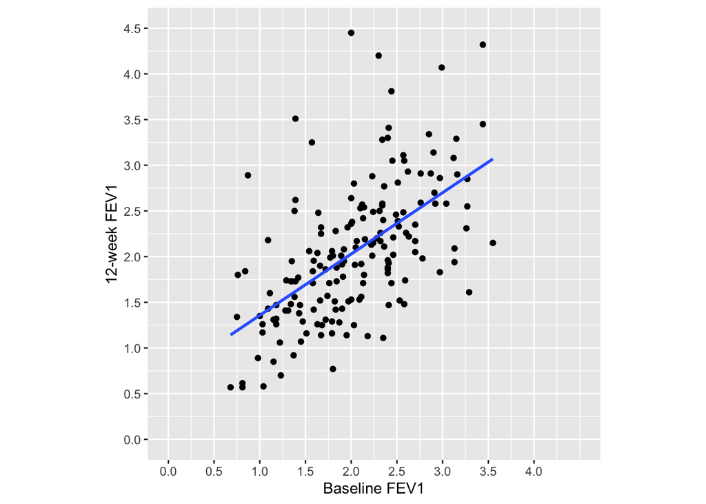

Adding in additional variables is done with the very simple code below:

```r
multilinear.model <- lm(
  formula = fev12 ~ treat + fev0,
  data = asthma_trial
)

summary(multilinear.model)
```

The new output gives three beta values which are compared to the crude model on the ratio:

[output not shown]

### Grouping variables

The perulung data has spirometry as an outcome variable. We aim to build a statistical model to assess the value of the presence or absence of respiratory symptoms in predicting poorer fev1.

We anticipate that age will likely be a confounder in this analysis so plan to keep the age groups separate in our analysis. This is achieved using dummy variables with the code below (NB: age was given in years and broken down into quintiles for analysis):

```r
perulung.multi <- perulung %>%
  mutate(
    g1 = if_else(agegrp==0, 0, 0),
    g2 = if_else(agegrp==1, 1, 0),
    g3 = if_else(agegrp==2, 1, 0),
    g4 = if_else(agegrp==3, 1, 0),
    g5 = if_else(agegrp==4, 1, 0)
  ) %>%
  lm(
    formula = fev1 ~ respsymptoms + g1 + g2 + g3 + g4 + g5,
    data = .
  )
```

The following table uses data from the output:

|  | coef | lower.ci | upper.ci |
| --- | --- | --- | --- |
| (Intercept) | 1.4442400 | 1.3967401 | 1.4917399 |
| respsymptoms | -0.0885672 | -0.1384721 | -0.0386624 |
| g1 | NA | NA | NA |
| g2 | 0.0714279 | 0.0065348 | 0.1363210 |
| g3 | 0.1095271 | 0.0447234 | 0.1743308 |
| g4 | 0.2883465 | 0.2234181 | 0.3532748 |
| g5 | 0.3850734 | 0.3197718 | 0.4503751 |

## Logistic regression

I find logistic regression quite a lot more tricky to get my head round than linear regression. Using [youtube videos](https://www.youtube.com/watch?v=vN5cNN2-HWE&t=507s) and some other resources I have prepared the below explanation.

### What is logistic regression trying to do?

Logistic regression is used for binary outcome variables. This could be, for example, the result of a coin toss, or the presence or absence of disease, visual impairment etc. The outcome is coded as:

- 0 - an event **not** happening. In medical statistics this is sometime called $H$ for *Health*
- 1 - an event happening. In medical stats speak: $D$ for *Disease*

We can now imagine a second variable that has a relationship with our outcome variable (an *explanatory* variable). To use the example from the StatQuest YouTube video, think of the relationship between mouse weight and obesity. Presence or absence of obesity is out binary outcome variable, and weight is our explanatory variable.

We can plot these variables on a scatter plot:

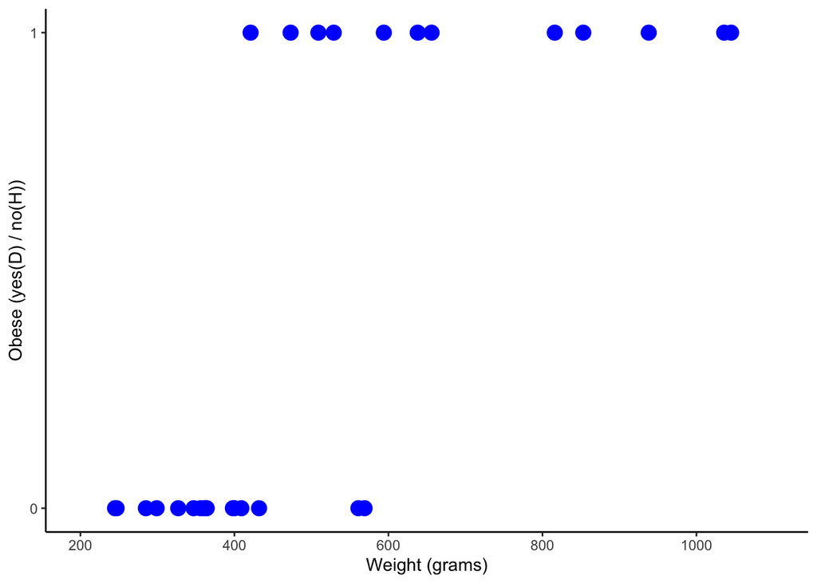

Look along the graph. At low values of $x$ there are very few obese mice, but at higher values almost all of them are obese. That’s to say: The *probability* of having the disease is low at low values of $x$ and high at higher values. We can work out the probability of having disease at any given value of $x$ by dividing the number of people with the disease ($D$) by the number of people in our sample ($H+D$).
$$P=\frac{D}{H+D}$$
Below is a graph with two key changes:

1. The $y$-axis is now “Probability of obesity”
2. We’ve worked out the probability of obesity at different values of $x$, plotted them as points and connected them with a line.

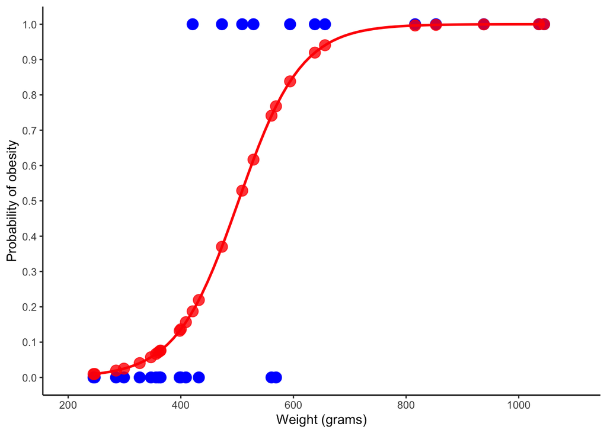

Wouldn’t it be great if we could do a regression on this line? This is what logistic regression is trying to do. The problem is, as we saw from linear regression, we can’t do a regression on the curvy line. And, to answer the question in this section’s heading, that’s what logistic regression is trying to do: do a linear regression on the probability of an event ($D$) over different values of an explanatory variable $x$.

### How does logistic regression work?

The trick to getting that curvy line straighter is a two step process.

**Step 1: Odds**
Firstly, the probabilities are converted to *odds*. Odds are easily understood and used by the g*mbling industry for that very reason. The odds ratio is the number of people with the disease divided by the number of people without.
$$odds=\frac{D}{H}$$
Odds can also be thought of as the ratio between the probability of something happening ($P_D$) and something not happening ($1-P_D$). There’s a [YouTube video](https://www.youtube.com/watch?v=ARfXDSkQf1Y&t=282s) that clearly explains it. That means that:
$$odds = \frac{P}{1-P}$$

By way of update, here’s how we’re doing on straightening out that line:

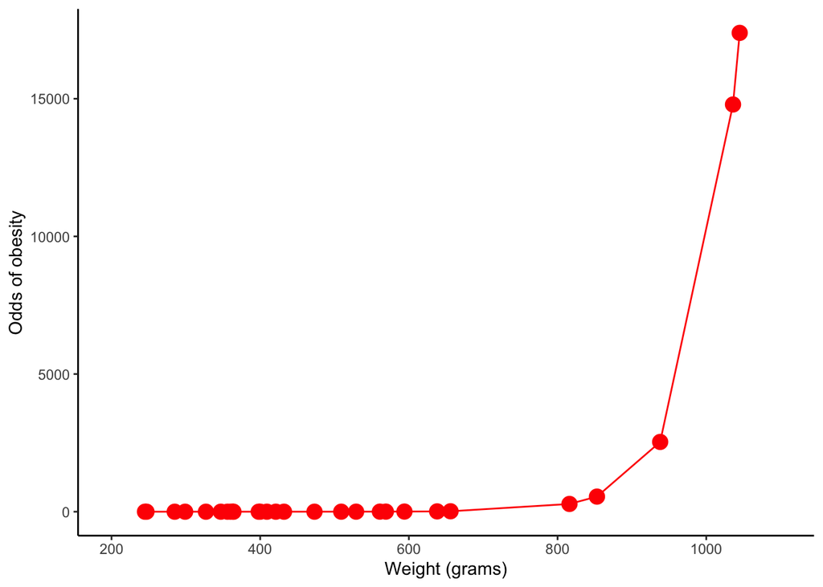

…not that well. When something is less likely to happen than no happen (i.e. $P<0.5$) then odds will always be between 0 and 1, but if $P\geq 0.5$ then the odds are between 1 and infinity ($\infty$). The reason the line is so bendy is because half our values are crammed into the 0-1 range, with the other half between 0 and $\infty$.

**Step 2: log(odds)**  
Roughly half our values on the $y$-axis (odds of obesity) are in the narrow, finite range between 0 and 1, and the other half are between 1 and $\infty$. We can solve this by taking the log of the odds. The log of odds value between 0 and 1 returns a number between 0 and $-\infty$, and any odds value between 1 and $\infty$ will be between 0 and $+\infty$; far better balanced. The line should now be straight. Graph to demonstrate:

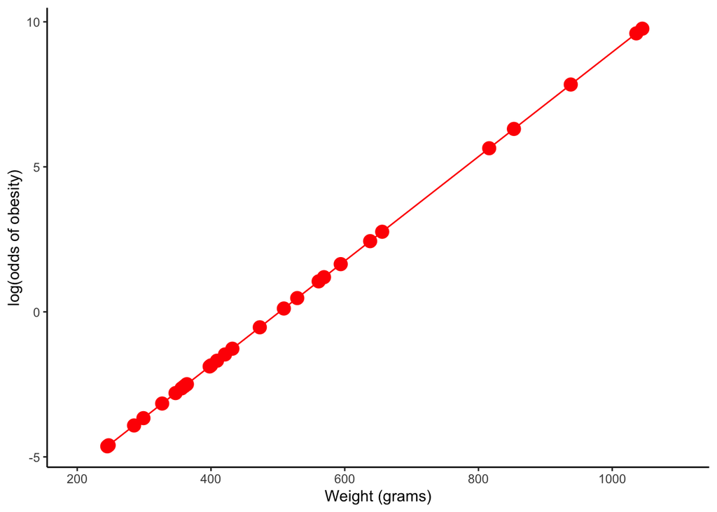

Look at that beautifully straight line. We can now do a linear regression on that and the coefficients will be the log(odds) of a mouse being obese. These can easily be converted back to odds, which are typically what you see in publications.

The formular for logistic regression is:
$$log(odds)=\beta_0 + \beta_1\cdot x$$

R does all these steps for you. Below are examples of how.

### Example: Crude logistic regression

**Data**  
Our example uses the *onch* data, which has outcome *mf* (microfilarial infection (river blindness)) and explanatory variables of location and age.

```r
onch <- read_dta("ONCH1302 (1).dta") %>%
  mutate(
    agebin = if_else(agegrp %in% c(0,1), 0, 1)
  )
```

**Mantel-Haenszel test**  
You can use a mantel haenszel test to estimate the odds ratio with the following code:

```
mantelhaen.test(onch$area,onch$mf,onch$agebin, alternative = "two.sided")
```

**Running a crude logistic regression model in R**  
A crude logistic regression is run using the following code:

```r
logit <- glm(
  formula = mf ~ area,
  data = onch,
  family = binomial(link = "logit")
)
```

Output formatted into a helpful table:

|  | coefficient | lower.ci | upper.ci |
| --- | --- | --- | --- |
| (Intercept) | 0.0511060 | -0.1163784 | 0.2188299 |
| area | 0.8810211 | 0.6511080 | 1.1125332 |

**Converting log(odds) to odds**  
The above outputs are all given in the log scale. In R they need to be converted into the ratio scale using the following formulas:

$$odds=e^{coef}$$
$$s.e.=\sqrt{(e^{coef})^2\times var}$$
In STATA the `logistic` function returns values on the ratio scale and `logit` function on the log scale. It is usually advisable to work in the log scale for as long as possible, converting to ratio scale as the final step.

The code below converts our output into the ratio scale (Note the `kable()` function merely formats the output for the Markdown document):

```r
linear.model_se   <- logit %>%
  summary() %>%
  coef() %>%
  data.frame %>%
  mutate(
    odds.ratio = exp(Estimate) ,
    var.diag = diag(vcov(logit)) %>% na.omit(),
    Std..Error = sqrt(Estimate^2*var.diag),
    P = Pr...z..
  ) %>%
  select(odds.ratio, Std..Error, P) %>%
  round(3)

linear.model_ci   <- logit %>%
  confint.default() %>%
  exp() %>%
  data.frame() %>%
  rename(
    lower.ci = X2.5..,
    upper.ci = X97.5..
  ) %>%
  round(3)

bind_cols(linear.model_se, linear.model_ci) %>% kable()
```

|  | odds.ratio | Std..Error | P | lower.ci | upper.ci |
| --- | --- | --- | --- | --- | --- |
| (Intercept) | 1.052 | 0.004 | 0.55 | 0.890 | 1.244 |
| area | 2.413 | 0.104 | 0.00 | 1.916 | 3.039 |

### Example: Multiple variable logistic regression

River blindness affects adults far more than it does children. So age is included in the analysis as a grouping variable. NB: the “age1” variable is used as a control so returns NA values. All the other age groups are compared to this one. The same goes for “control”, which are participants from an area other than the one we’re interested in.

```r
onchage.mulyi <- onch %>%
  mutate(
    age1 = if_else(agegrp == 0, 0, 0), # reference age
    age2 = if_else(agegrp == 1, 1, 0),
    age3 = if_else(agegrp == 2, 1, 0),
    age4 = if_else(agegrp == 3, 1, 0)
  ) %>%
  glm(
    mf ~ area + age1 + age2 + age3 + age4,
    data = .,
    family = binomial(link="logit")
  )
```

|  | odds.ratio | lower.ci | upper.ci |
| --- | --- | --- | --- |
| (Intercept) | 0.1473754 | 0.0991888 | 0.2145632 |
| area | 3.0832239 | 2.3598170 | 4.0492517 |
| age1 | NA | NA | NA |
| age2 | 2.5991319 | 1.6896034 | 4.0396884 |
| age3 | 9.7654104 | 6.5443156 | 14.8185868 |
| age4 | 17.6415839 | 11.6528930 | 27.1890105 |

We can see as you get older your risk of river blindness goes up. So what if we compare children to adults by grouping age1 & age2 and age3 & age4 groups?:

```r
onch.agebin <- onch %>%
  glm(
    mf ~ area + agebin,
    data = .,
    family = binomial(link="logit")
  )
onch.agebin_co <- onch.agebin %>%
  summary() %>%
  coef() %>%
  exp() %>%
  round(3) %>%
  data.frame() %>%
  select(Estimate) %>%
  rename(odds.ratio = Estimate)
onch.agebin_ci <- onch.agebin %>%
  confint.default() %>%
  exp() %>%
  round(3) %>%
  data.frame() %>%
  rename(
    lower.ci = X2.5..,
    upper.ci = X97.5..
  )

bind_cols(onch.agebin_co, onch.agebin_ci) %>% kable()
```

|  | odds.ratio | lower.ci | upper.ci |
| --- | --- | --- | --- |
| (Intercept) | 0.243 | 0.183 | 0.321 |
| area | 3.265 | 2.502 | 4.262 |
| agebin | 7.633 | 5.799 | 10.046 |

NB: You don’t need to have area and age bin as dummy variables because they’re both binary.

## Interaction in regression models

Distinction between *interaction* and *confounding* can be unclear.

> Interaction (sometimes called *effect modification*) arises when the association between an exposure and disease risk varies across the *levels* of a third factor.

Interaction can be tested:

- graphically
- by stratifying the analysis
- using an *interaction test* within your logistic regression code

### Interaction versus confounding

**Confounding**

- refers to incorrect estimates of the underlying exposure-disease associations.
- stratified analysis will show that the association between the exposure and outcome is the same at each level of the third variable…
- …but may be different to the association observed in the crude analysis.

**Interaction**

- Gives more specific information on the association between exposure and outcome
- i.e., the association varies at different levels of the third factor.

### Interaction test

- Null hypothesis = “there is no interaction in the test population
- P-value = the probability of the observed difference in a sample taken from the population where the null hypothesis is true.

This is the R syntax for including an interaction test:

```r
glm(
   family = binomial(link = "logit"),
   formula = mf ~ area + agebin + area:agebin,
   data = onch
) %>% coef() %>% exp() %>% data.frame() %>% round(3)
```

```
##                 .
## (Intercept) 0.299
## area        2.416
## agebin      5.801
## area:agebin 1.592
```

If the grouping variable is not binary:

```r
onch.agegroup <- onch %>%
  mutate(
    g1 = if_else(agegrp==0, 0, 0),
    g2 = if_else(agegrp==1, 1, 0),
    g3 = if_else(agegrp==2, 1, 0),
    g4 = if_else(agegrp==3, 1, 0),
  ) %>%
  glm(
    family = binomial(link = "logit"),
   formula = mf ~ area + g1 + g2 + g3 + g4 + area:(g1 + g2 + g3 + g4),
   data = .
  )

onch.agegroup_co <- onch.agegroup %>%
  summary() %>%
  coef() %>%
  data.frame() %>%
  mutate(
    Estimate = exp(Estimate),
    var.diag = diag(vcov(onch.agegroup)) %>% na.omit(),
    Std..Error = sqrt(Estimate^2*var.diag)
  ) %>%
  rename(
    Odds.ratio = Estimate,
    P = Pr...z..
  ) %>%
  select(
    Odds.ratio, Std..Error, P
  ) %>%
  round(3)

onch.agegroup_ci <- onch.agegroup %>%
  confint.default() %>%
  na.omit() %>%
  exp() %>%
  round(3)

bind_cols(onch.agegroup_co, onch.agegroup_ci) %>% kable()
```

|  | Odds.ratio | Std..Error | P | 2.5 % | 97.5 % |
| --- | --- | --- | --- | --- | --- |
| (Intercept) | 0.208 | 0.057 | 0.000 | 0.121 | 0.356 |
| area | 1.828 | 0.637 | 0.084 | 0.923 | 3.619 |
| g2 | 2.118 | 0.795 | 0.046 | 1.015 | 4.420 |
| g3 | 6.964 | 2.151 | 0.000 | 3.802 | 12.757 |
| g4 | 10.500 | 3.353 | 0.000 | 5.615 | 19.636 |
| area:g2 | 1.388 | 0.643 | 0.479 | 0.560 | 3.439 |
| area:g3 | 1.664 | 0.690 | 0.220 | 0.738 | 3.751 |
| area:g4 | 2.588 | 1.134 | 0.030 | 1.097 | 6.107 |

## Practical

This is a worked through example as part of the course.

Learning objectives:

- To provide experience of applying the methods covered in the course to a sizeable dataset without the detailed instructions provided in earlier practical sessions.
- Students are welcome to use their own datasets.

Dataset `astnutr` contains the results of a study which examined whether certain dietary anti-oxidants (beta-carotene & vitamin C) might be related to the risk of asthma. Anti-oxidants protect cells from oxidative damage and therefore may prevent lung damage from pollutants and reduce the potential for narrowing of the airways to a variety of noxious agents. The researchers approached subjects who were registered with 20 GP practices in South East London. Using the practice computerised database, they identified subjects with a doctor diagnosis of asthma, between the ages of 16 to 50 years. They also selected subjects, who were non-asthmatic within the same age range. Each subject was then sent out a self-completion questionnaire. This questionnaire included a food frequency measure, which asks respondents to record how often they consume a wide variety of different food items. The results from this were then converted into micronutrients by using a computer algorithm based on dietary food tables i.e. the amount of vitamin C in one orange. Thus, the researchers were able to derive weekly intakes of beta-carotene and vitamin C . The response rates for completed questionnaires were 74% (1270 subjects) and 68% (1812) for asthmatics and non-asthmatics respectively. The variables are:

| Variable number | Variable name | Description |
| --- | --- | --- |
| 1. | patno | Patient number |
| 2. | ageyear | Age in years |
| 3. | agegroup | Age group (16-20, 21-25, 26-30, 31-35, 36-40, 41-45, 46-50) |
| 4. | male | 1=male, 0=female |
| 5. | soccl | Social class (I, II, III non-manual, III manual, combined IV &V) |
| 6. | vitc | Vitamin C (mg/week) |
| 7. | logvitc | Log vitamin C |
| 8 | bc | Beta carotene (mg/week) |
| 9 | logbc | Log beta carotene |
| 10. | asthma | 1=yes, 0=no |

Investigate the evidence for an association between asthma and consumption of vitamin C and beta-carotene, controlling for possible confounding variables. You should create variables containing quintiles of nutrient consumption using the `xtile` command: for example:

`xtile vitcq5=vitc, nq(5)`

Make sure that you check any linearity assumptions, and investigate possible interactions. Compare whether your conclusions differ depending on whether you use quintiles or the original variable. Write a “do” file which performs your whole analysis.

**Understanding the data**  
Prior to beginning our analysis it is important that we try to understand the our data and its distribution. Considerations may include:

- Distribution: Is the exposure (and outcome) normally distributed?
  - Density plots and histograms can help
  - Is this solved by using the log scale?
- What is the nature of the data?
  - Continuous, binary, categoric
  - Are there outliers?
  - Would it be better to analyse the data in bins than on continuous scale (e.g., as with age or with exposures as recommended in this question?) The advantage of doing analysis this way could improve communication of results and reduce the effect of outliers.

1. Take the log of all the beta-carotene values and plot them instead. The `log()` function in R uses natural log (that’s to the base $e$). This is the more common method used by convention (and it has already been done for us in the question).
2. Use a log scale on either one of the axis (depending on whether dependent or independent variable). Confusingly this is usually done to the base 10 using the `scale_x_log10()` function in ggplot.

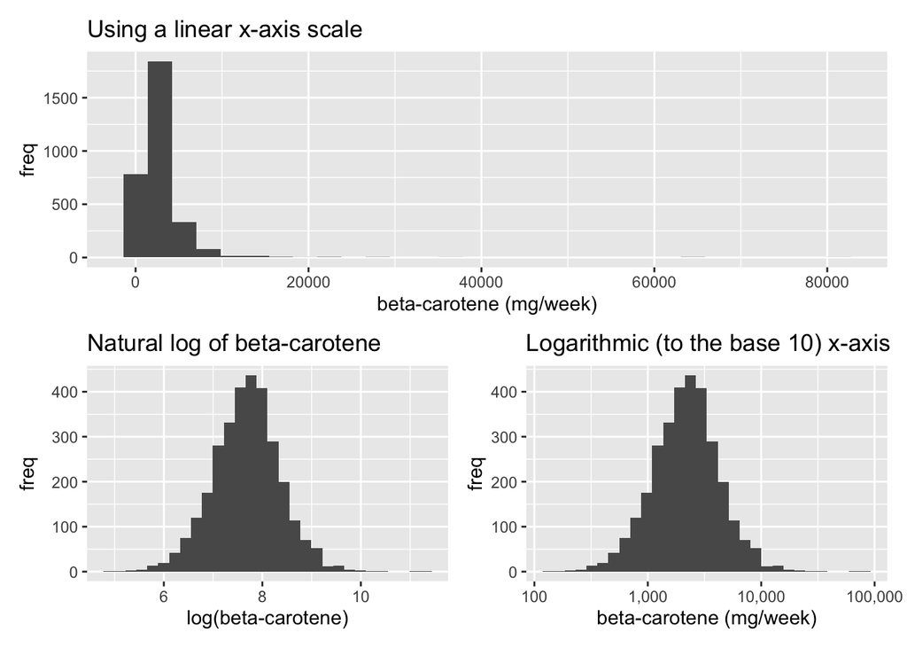

**Crude analyses**

```r
glm(
  data = astnutr,
  family = binomial(link = "logit"),
  formula = asthma ~ vitc
) %>% summary() %>% coef()
```

```
##                 Estimate   Std. Error   z value     Pr(>|z|)
## (Intercept) -0.266475531 0.0626691541 -4.252100 2.117749e-05
## vitc        -0.000634024 0.0003646314 -1.738808 8.206855e-02
```

```r
glm(
  data = astnutr,
  family = binomial(link = "logit"),
  formula = asthma ~ bc
) %>% summary() %>% coef()
```

```
##                  Estimate   Std. Error   z value     Pr(>|z|)
## (Intercept) -1.396681e-01 6.098280e-02 -2.290287 2.200471e-02
## bc          -8.004782e-05 1.859066e-05 -4.305809 1.663763e-05
```

Splitting the independant variables into quintiles

```r
astnutr <- astnutr %>%
  mutate(
    vitc.quint = ntile(vitc, n=5),
    bc.quint = ntile(bc, n=5),
    vitc1 = if_else(vitc.quint == 1, 0, 0),
    vitc2 = if_else(vitc.quint == 2, 1, 0),
    vitc3 = if_else(vitc.quint == 3, 1, 0),
    vitc4 = if_else(vitc.quint == 4, 1, 0),
    vitc5 = if_else(vitc.quint == 5, 1, 0),
    bc1 = if_else(bc.quint == 1, 0, 0),
    bc2 = if_else(bc.quint == 2, 1, 0),
    bc3 = if_else(bc.quint == 3, 1, 0),
    bc4 = if_else(bc.quint == 4, 1, 0),
    bc5 = if_else(bc.quint == 5, 1, 0)
  )
astnutr.quint <- glm(data = astnutr, formula = asthma ~ bc1 + bc2 + bc3 + bc4 + bc5 + vitc1 + vitc2 + vitc3 + vitc4 + vitc5 + ( bc1 + bc2 + bc3 + bc4 + bc5):(vitc1 + vitc2 + vitc3 + vitc4 + vitc5), family = binomial(link="logit"))


astnutr.quint_co <- astnutr.quint %>%
  summary() %>%
  coef() %>%
  data.frame() %>%
  mutate(
    Estimate = exp(Estimate),
    var.diag = diag(vcov(astnutr.quint)) %>% na.omit(),
    Std..Error = sqrt(Estimate^2*var.diag)
  ) %>%
  rename(
    Odds.ratio = Estimate,
    P = Pr...z..
  ) %>%
  select(
    Odds.ratio, Std..Error, P
  ) %>%
  round(3)

astnutr.quint_ci <- astnutr.quint %>%
  confint.default() %>%
  na.omit() %>%
  exp() %>%
  round(3)

bind_cols(astnutr.quint_co, astnutr.quint_ci) %>% kable()
```

|  | Odds.ratio | Std..Error | P | 2.5 % | 97.5 % |
| --- | --- | --- | --- | --- | --- |
| (Intercept) | 1.154 | 0.135 | 0.220 | 0.918 | 1.452 |
| bc2 | 0.684 | 0.133 | 0.050 | 0.468 | 1.000 |
| bc3 | 0.731 | 0.183 | 0.210 | 0.449 | 1.193 |
| bc4 | 0.643 | 0.192 | 0.139 | 0.358 | 1.155 |
| bc5 | 0.186 | 0.120 | 0.009 | 0.052 | 0.660 |
| vitc2 | 0.843 | 0.172 | 0.400 | 0.565 | 1.256 |
| vitc3 | 0.716 | 0.178 | 0.178 | 0.440 | 1.165 |
| vitc4 | 0.445 | 0.136 | 0.008 | 0.244 | 0.810 |
| vitc5 | 0.866 | 0.292 | 0.670 | 0.447 | 1.678 |
| bc2:vitc2 | 0.963 | 0.289 | 0.901 | 0.535 | 1.736 |
| bc2:vitc3 | 1.151 | 0.394 | 0.682 | 0.588 | 2.252 |
| bc2:vitc4 | 2.432 | 0.980 | 0.027 | 1.104 | 5.359 |
| bc2:vitc5 | 1.514 | 0.690 | 0.363 | 0.620 | 3.701 |
| bc3:vitc2 | 0.763 | 0.261 | 0.429 | 0.390 | 1.492 |
| bc3:vitc3 | 1.476 | 0.550 | 0.296 | 0.711 | 3.065 |
| bc3:vitc4 | 2.232 | 0.931 | 0.054 | 0.985 | 5.056 |
| bc3:vitc5 | 0.933 | 0.419 | 0.877 | 0.387 | 2.249 |
| bc4:vitc2 | 0.984 | 0.391 | 0.969 | 0.452 | 2.144 |
| bc4:vitc3 | 1.547 | 0.626 | 0.281 | 0.700 | 3.421 |
| bc4:vitc4 | 1.118 | 0.499 | 0.803 | 0.466 | 2.682 |
| bc4:vitc5 | 1.044 | 0.489 | 0.927 | 0.416 | 2.616 |
| bc5:vitc2 | 2.659 | 2.007 | 0.195 | 0.606 | 11.671 |
| bc5:vitc3 | 3.170 | 2.262 | 0.106 | 0.783 | 12.834 |
| bc5:vitc4 | 5.290 | 3.826 | 0.021 | 1.281 | 21.834 |
| bc5:vitc5 | 3.013 | 2.202 | 0.131 | 0.719 | 12.624 |

```r
astnutr %>% mutate(
  s1 = if_else(soccl == 1, 0, 0),
  s2 = if_else(soccl == 2, 1, 0),
  s3 = if_else(soccl == 3, 1, 0),
  s4 = if_else(soccl == 4, 1, 0),
  s5 = if_else(soccl == 5, 1, 0)
) %>%
  glm(
    data = .,
    family = binomial(link="logit"),
    formula = asthma ~ bc1 + bc2 + bc3 + bc4 + bc5 + ageyear + bc:(s1+s2+s3+s4+s5)
  ) %>% summary() %>% coef() %>% data.frame %>% select(!c(Std..Error, z.value)) %>% mutate(Estimate = exp(Estimate)) %>% round(3)
```

```
##             Estimate Pr...z..
## (Intercept)    1.964    0.000
## bc2            0.775    0.028
## bc3            0.756    0.018
## bc4            0.628    0.000
## bc5            0.509    0.000
## ageyear        0.979    0.000
## bc:s2          1.000    0.564
## bc:s3          1.000    0.172
## bc:s4          1.000    0.179
## bc:s5          1.000    0.223
```

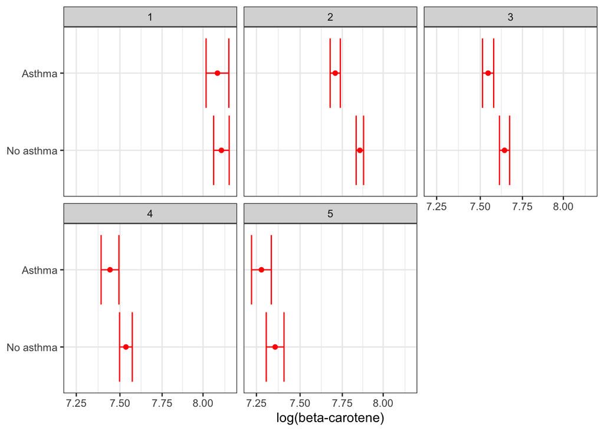

```r
astnutr %>% select(bc, soccl, asthma) %>% ggplot(aes(x=log(bc), y=factor(asthma))) +
  # geom_jitter(alpha=0.2) +
  stat_summary(
    fun.data = mean_se,
    geom = "errorbar", colour="red"
  ) +
  stat_summary(fun = mean, geom = "point", colour="red") +
  facet_wrap(~soccl) +
  theme_bw() +
  scale_y_discrete(
    labels = c("No asthma", "Asthma")
  ) +
  scale_x_log10() +
  labs(
    y = NULL,
    x = "log(beta-carotene)"
  )
```

```r
astnutr %>% mutate(
  s1 = if_else(soccl == 1, 0, 0),
  s2 = if_else(soccl == 2, 1, 0),
  s3 = if_else(soccl == 3, 1, 0),
  s4 = if_else(soccl == 4, 1, 0),
  s5 = if_else(soccl == 5, 1, 0)
) %>%
glm(
  data = .,
  family = binomial(link="logit"),
  formula = asthma ~ bc*(s1+s2+s3+s4+s5)
) %>% summary() %>% coef() %>% data.frame() %>% mutate(Estimate = exp(Estimate)) %>% round(3)
```

```
##             Estimate Std..Error z.value Pr...z..
## (Intercept)    0.401      0.207  -4.416    0.000
## bc             1.000      0.000  -0.774    0.439
## s2             1.924      0.237   2.762    0.006
## s3             2.519      0.237   3.898    0.000
## s4             2.007      0.253   2.757    0.006
## s5             2.570      0.238   3.968    0.000
## bc:s2          1.000      0.000  -1.211    0.226
## bc:s3          1.000      0.000  -0.995    0.320
## bc:s4          1.000      0.000   0.039    0.969
## bc:s5          1.000      0.000   0.047    0.963
```

```r
lm(
   data = astnutr,
   family = binomial(link="logit"),
   formula = asthma ~ bc + soccl + bc*soccl
) %>% summary() %>% coef() %>% data.frame() %>% mutate(Estimate = exp(Estimate)) %>% round(3)
```

```
##             Estimate Std..Error t.value Pr...t..
## (Intercept)    1.382      0.030  10.644    0.000
## bc             1.000      0.000  -2.123    0.034
## soccl          1.040      0.009   4.304    0.000
## bc:soccl       1.000      0.000   0.509    0.611
```